# Midterm BANA7038

Garima Sharma

November 27, 2015

#### Summary

In this module, we are analyzing the data provided for Aircraft (with number of observations = 800).

Firstly, we are reading the data, calculating sample size, cleaning the data based on the conditions provided for height, speed_ground, speed_air, duration and distance, visualizing the data, selecting the parameters, model checking, re-modeling with higher degree, determining model adequacy and checking goodness of fit.

Based on the various functions and tests performed on the data, we can conclude that the model is a best fit and landing distance is dependent on the make of aircraft, ground speed and height over threshold.

Analysing the model,

y = $\beta_0$ + $\beta_1$x1 + $\beta_2$x2 + $\beta_3$x2 + $\beta_4$x3^2

where $\beta_i$ are the co-efficients which are represented as:

y(distance) = 1774.48 + 402.75 * x1 + 13.71 * x2 - 68.82 * x3 + 0.69 * $x3^2$

x1 = Type of aircraft with Boeing = 1 and Airbus = 0

x2 = height

x3 = speed_ground

**1. Reading the data**

##### Clean Memory and Read Data

```r
rm(list=ls())
landingData = read.csv("C:/Garima/2nd Flex/DAM/MidTerm/landing.csv", header = TRUE)
```

To read data from csv file into dataset I have used the function read.csv() and imported data to landingData.

**2. Data Exploration**

##### Calculating Sample Size

```r
n = dim(landingData)[1]
variables = names(landingData)
```

Sample size can be obtained using the above parameters. We can see that no. of observation in our sample is 800 and names of the variables are aircraft, duration, no_pasg, speed_ground, speed_air, height, pitch, distance.

##### Visualizing Data

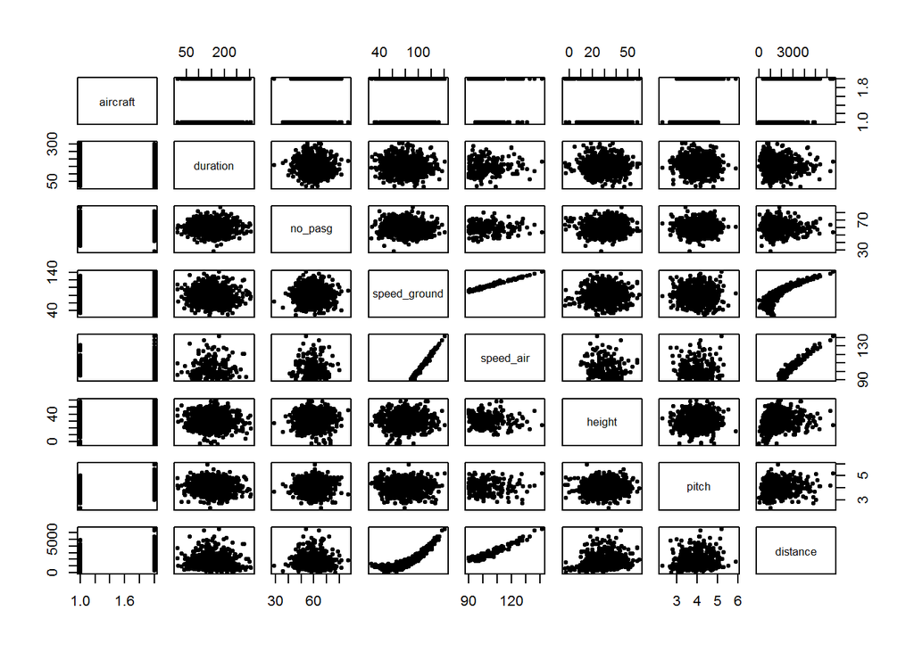

We can further analyze the numeric variables of landing data by plotting their histograms.

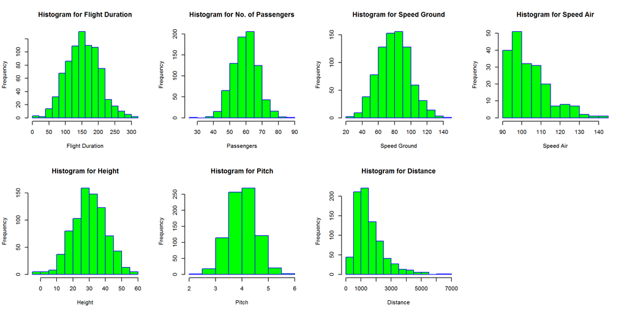

We can observe the data further using the summary function. It can be seen that there are two types of aircrafts i.e. Airbus and Boeing.

Speed_Air has 600 NA’s.

```
##    aircraft      duration         no_pasg       speed_ground
##  airbus:400   Min.   : 14.76   Min.   :29.00   Min.   : 27.74
##  boeing:400   1st Qu.:119.49   1st Qu.:55.00   1st Qu.: 65.87
##               Median :153.95   Median :60.00   Median : 79.64
##               Mean   :154.01   Mean   :60.13   Mean   : 79.54
##               3rd Qu.:188.91   3rd Qu.:65.00   3rd Qu.: 92.33
##               Max.   :305.62   Max.   :87.00   Max.   :141.22
##
##    speed_air          height           pitch          distance
##  Min.   : 90.00   Min.   :-3.546   Min.   :2.284   Min.   :  34.08
##  1st Qu.: 96.16   1st Qu.:23.338   1st Qu.:3.658   1st Qu.: 900.95
##  Median :100.99   Median :30.147   Median :4.020   Median :1267.44
##  Mean   :103.83   Mean   :30.122   Mean   :4.018   Mean   :1544.52
##  3rd Qu.:109.48   3rd Qu.:36.981   3rd Qu.:4.388   3rd Qu.:1960.44
##  Max.   :141.72   Max.   :59.946   Max.   :5.927   Max.   :6533.05
##  NA's   :600
```

##### Cleaning the data

According to question, I will consider the values for normal flights.

For duration, normal flight should always be greater than 40min.

```r
landingData1 = landingData[ (landingData$duration > 40), ]
```

For normal landing, 140mph >= speed_ground >= 30mph and 140mph >= speed_air >= 30mph.

```r
landingData2 = landingData1[(landingData1$speed_ground >= 30), ]
landingData3 = landingData2[(landingData2$speed_ground <= 140), ]
landingData4 = landingData3 [!is.null(landingData3$speed_air >= 30),]
landingData5 = landingData4 [!is.null(landingData4$speed_air <= 140),]
```

Height of the aircraft must be at least 6 meters high.

```r
landingData6 = landingData5[(landingData5$height >= 6), ]
```

Length of an airport runway is less than 6000 feet.

```r
myLandingData = landingData6[(landingData6$distance < 6000), ]
```

Cleaned data is myLandingData and no. of observations are 781.

**3. Visualizing Data**

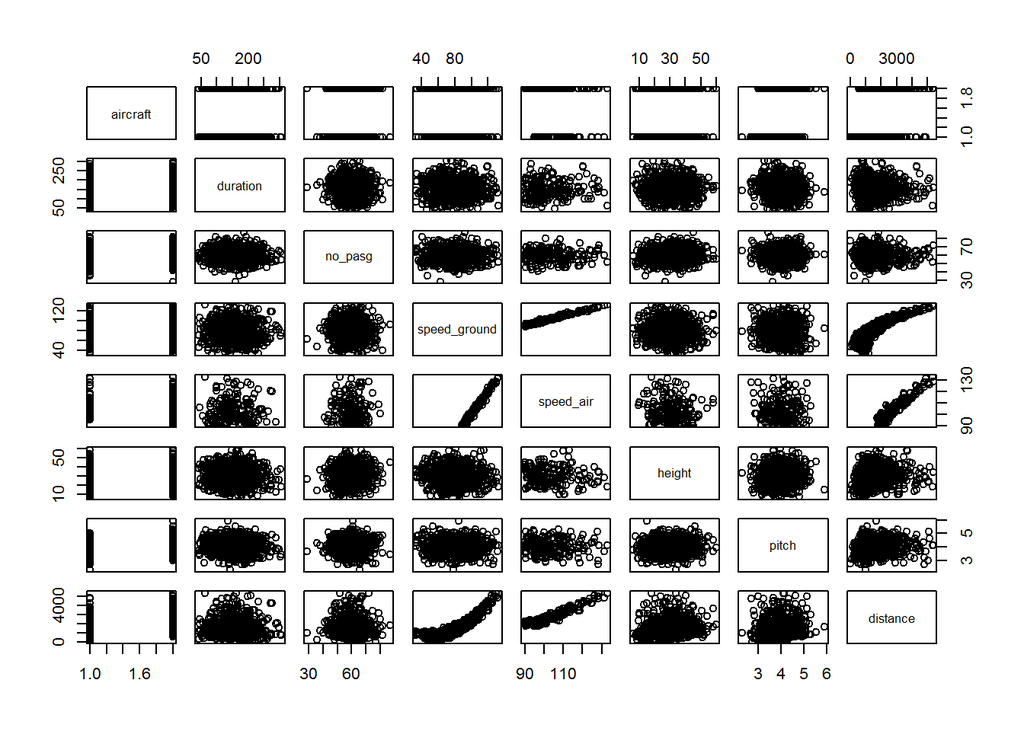

```
##
## Call:
## lm(formula = distance ~ aircraft + duration + no_pasg + speed_ground +
##     speed_air + height + pitch)
##
## Residuals:
##     Min      1Q  Median      3Q     Max
## -287.36  -85.69   11.25   83.50  359.85
##
## Coefficients:
##                  Estimate Std. Error t value Pr(>|t|)
## (Intercept)    -6229.6000   161.7147 -38.522   <2e-16 ***
## aircraftboeing   437.9428    21.2621  20.597   <2e-16 ***
## duration           0.1276     0.2039   0.626    0.532
## no_pasg           -1.9812     1.3780  -1.438    0.152
## speed_ground      -3.5464     6.4160  -0.553    0.581
## speed_air         85.5469     6.5221  13.117   <2e-16 ***
## height            13.6756     1.0386  13.168   <2e-16 ***
## pitch            -13.4897    18.6077  -0.725    0.469
## ---
## Signif. codes:  0 '***' 0.001 '**' 0.01 '*' 0.05 '.' 0.1 ' ' 1
##
## Residual standard error: 134.5 on 187 degrees of freedom
##   (586 observations deleted due to missingness)
## Multiple R-squared:  0.9747, Adjusted R-squared:  0.9738
## F-statistic:  1030 on 7 and 187 DF,  p-value: < 2.2e-16
```

**4. Selecting the variables**

1. For variable Aircraft,

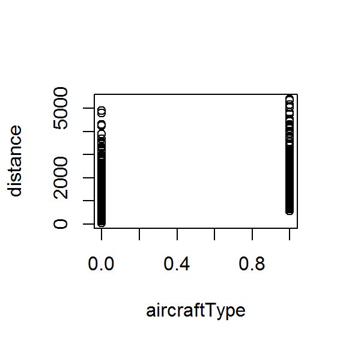

```r
aircraftType = rep(1,length(aircraft)) * (aircraft == "boeing")
plot(aircraftType, distance)
```

After plotting the aircraft type vs distance, we can observe that mean distance of aircraft boeing is higher than the mean distance of aircraft airbus.

2. For variable Height,

We will keep height variable as we can observe from least square fitted model that height has high importance.

3. For variable Speed_ground,

4. For variable Speed_Air,

Since this variable has 600 NAs, so we can analyze our data to find if there is some other variable which can act as its substitute.

Degree of co-relation between ‘speed_air’ and other variables can be observed by:

```r
cor(myLandingData[,2:7],use="pairwise.complete.obs")
```

```
##                 duration       no_pasg speed_ground     speed_air
## duration      1.00000000 -3.638958e-02 -0.048970252  4.454351e-02
## no_pasg      -0.03638958  1.000000e+00 -0.001489012  2.242968e-05
## speed_ground -0.04897025 -1.489012e-03  1.000000000  9.883475e-01
## speed_air     0.04454351  2.242968e-05  0.988347471  1.000000e+00
## height        0.01111923  3.730883e-02 -0.051671805 -8.672929e-02
## pitch        -0.04675348 -1.444759e-02 -0.051670337 -4.826810e-02
##                   height       pitch
## duration      0.01111923 -0.04675348
## no_pasg       0.03730883 -0.01444759
## speed_ground -0.05167181 -0.05167034
## speed_air    -0.08672929 -0.04826810
## height        1.00000000  0.03473959
## pitch         0.03473959  1.00000000
```

We can see from correlation coefficient of 0.99 between speed_air and speed_ground that they both vary linearily.

We can plot these variables for better understanding:

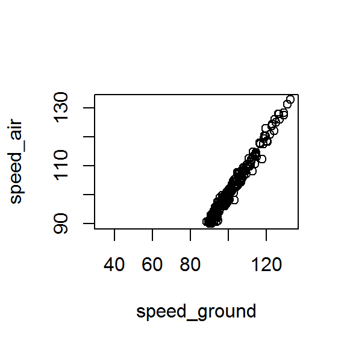

```r
plot(speed_ground, speed_air)
```

It can be observed that speed_air varies linearily with speed_ground for speed_ground > 90.

**5. Model Checking**

##### New Linear Regression Model for the above variables:

```
##
## Call:
## lm(formula = distance ~ aircraftType + height + speed_ground)
##
## Residuals:
##     Min      1Q  Median      3Q     Max
## -712.96 -225.11  -90.59  130.05 1465.84
##
## Coefficients:
##                Estimate Std. Error t value Pr(>|t|)
## (Intercept)  -2528.0208    70.5193  -35.85   <2e-16 ***
## aircraftType   496.6210    25.1296   19.76   <2e-16 ***
## height          14.2824     1.2911   11.06   <2e-16 ***
## speed_ground    42.5437     0.6661   63.87   <2e-16 ***
## ---
## Signif. codes:  0 '***' 0.001 '**' 0.01 '*' 0.05 '.' 0.1 ' ' 1
##
## Residual standard error: 350.7 on 777 degrees of freedom
## Multiple R-squared:  0.8503, Adjusted R-squared:  0.8497
## F-statistic:  1471 on 3 and 777 DF,  p-value: < 2.2e-16
```

Plotting the regression for each independent variable:

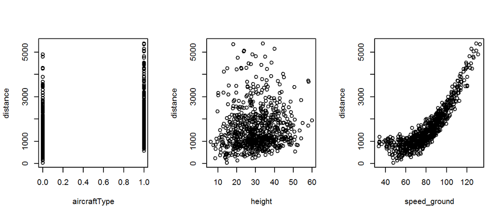

We can observe from the plots that speed_ground is not completely linear with distance.

To verify it further, we can generate residual plots:

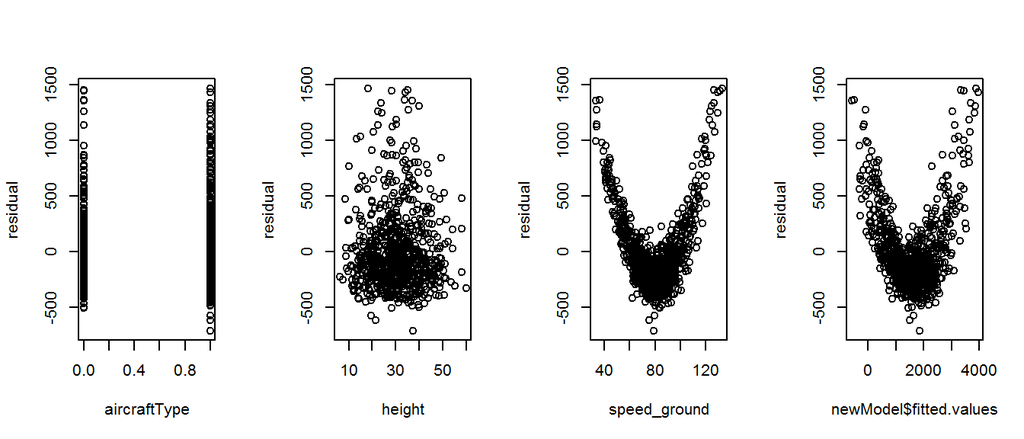

It can be observed from residual plots that speed_ground doesn’t hold a linear relationship with distance. When the value of speed_ground increases above 80, there exist a linear relationship however, for the complete values between 40mph to 80mph, there exist a quadritic relationship.

**Re-Modeling**

We can further perform the re-modeling by adding a higher degree variable in the model mentioned above.

```
##
## Call:
## lm(formula = distance ~ aircraftType + height + speed_ground +
##     speedGroundSq)
##
## Residuals:
##     Min      1Q  Median      3Q     Max
## -486.02  -93.92   -4.37   93.33  415.17
##
## Coefficients:
##                 Estimate Std. Error t value Pr(>|t|)
## (Intercept)   1774.47730   70.37080   25.22   <2e-16 ***
## aircraftType   402.74539    9.83732   40.94   <2e-16 ***
## height          13.71309    0.50024   27.41   <2e-16 ***
## speed_ground   -68.81559    1.69824  -40.52   <2e-16 ***
## speedGroundSq    0.69113    0.01042   66.34   <2e-16 ***
## ---
## Signif. codes:  0 '***' 0.001 '**' 0.01 '*' 0.05 '.' 0.1 ' ' 1
##
## Residual standard error: 135.8 on 776 degrees of freedom
## Multiple R-squared:  0.9776, Adjusted R-squared:  0.9774
## F-statistic:  8452 on 4 and 776 DF,  p-value: < 2.2e-16
```

Residual Plots:

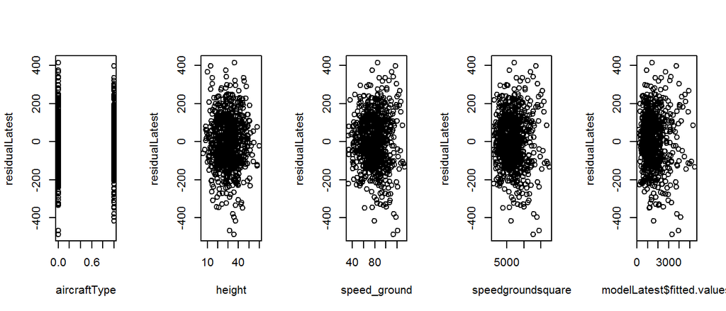

**7. Model Adequacy**

##### 7.1 Plotting Residuals of other parameters

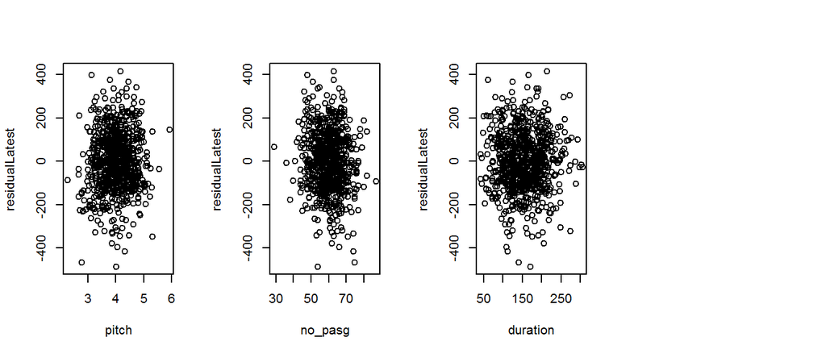

```r
par(mfrow=c(1,4))
plot(residualLatest~pitch)
plot(residualLatest~no_pasg)
plot(residualLatest~duration)
```

As we can observe that, non-model parameters do not exhibit any specific pattern hence it demonstrates that the model is a good fit.

##### 7.2 Calculating coefficient of Determination

A high value of R^2 of 0.9775627 demonstrates that the model is a good fit.

##### 7.3 Performing T Test

Also since the calculated p-values are less than $\alpha = 0.05$ so it again proves that we can reject the null hypothesis.

Hence we can conclude that ‘distance’ demonstrates a relationship with all the variables.

##### 7.4 Performing F Test

```r
meanDis = mean(distance)
SST=sum((distance-meanDis)^2)
SSRes=sum((distance-modelLatest$fitted.values)^2)
SSR=sum((modelLatest$fitted.values-meanDis)^2)
fVal=SSR/2/(SSRes/(n-2-1))
```

##### 7.5 Calculating Multicolinearity

```r
modelN <- lm(distance ~ aircraftType + height + speed_ground)
#library(car)
#vif(model4)
```

**8. Conclusion**

#### We can conclude from the above observations that this model is the best fit model due to the following reasons:

1. All the variables plays a significant role in this model.
2. Resiual plots do not follow a particular pattern and is distributed randomly.
3. P value of 2.2e-16 is very small and less than 0.05.
4. R^2 of 0.977 is very near to 1 hence the model can determine 97.7% of the variability in distance.
5. Landing distance is dependent on the make of aircraft, ground speed and height over threshold.